# NYC Healthcare Access Deserts: 10-Minute Walk to Care

## 2.4 Intersect Isochrones with Census Tracts

```r
# Add tract area to tracts (once)
tracts <- tracts %>%
  mutate(tract_area = st_area(.))

# Intersect isochrones with tracts, keep geometry
intersections <- tracts %>%
  st_intersection(isos)

# Calculate overlap area per tract
tract_overlap <- intersections %>%
  mutate(overlap_area = st_area(.)) %>%
  st_drop_geometry() %>%          # <-- DROP GEOMETRY HERE
  group_by(GEOID) %>%
  summarise(
    access_area = sum(overlap_area, na.rm = TRUE),
    .groups = "drop"
  )

# Join back to original tract areas (non-sf)
tract_coverage <- tracts %>%
  st_drop_geometry() %>%          # <-- DROP GEOMETRY HERE
  select(GEOID, tract_area) %>%
  left_join(tract_overlap, by = "GEOID") %>%
  mutate(
    access_area = replace_na(access_area, units::set_units(0, "ft^2")),
    perc_covered = as.numeric(access_area / tract_area)
  ) %>%
  select(GEOID, perc_covered)

# Final tracts object (geometry from tracts)
tracts <- tracts %>%
  left_join(tract_coverage, by = "GEOID") %>%
  mutate(perc_covered = replace_na(perc_covered, 0))
```

## 2.5 Add Socioeconomic Data (ACS 2023)

**Pull ACS 2023: income, poverty, uninsured, AND race/ethnicity data**

```r
get_ses <- function(cache_dir = CACHE_DIR) {
  cache_file <- file.path(cache_dir, "ses_acs2023_full.csv")

  if (file.exists(cache_file)) {
    cat("Loading cached ACS 2023 SES + demographic data...\n")
    return(read_csv(cache_file, col_types = cols(GEOID = col_character())))
  }

  # === STEP 1: PULL ALL VARIABLES ===
  vars <- c(
    # Income & Poverty
    median_income = "B19013_001",
    poverty_total = "B17001_001",
    poverty_below = "B17001_002",

    # Uninsured (age 18-64)
    uninsured_m_18_24 = "B27001_005",
    uninsured_m_25_34 = "B27001_008",
    uninsured_m_35_64 = "B27001_011",
    uninsured_f_18_24 = "B27001_033",
    uninsured_f_25_34 = "B27001_036",
    uninsured_f_35_64 = "B27001_039",

    # Total Population & Race/Ethnicity
    total_population = "B01003_001",
    white_alone = "B02001_002",
    black_alone = "B02001_003",
    aian_alone = "B02001_004",
    asian_alone = "B02001_005",
    nhpi_alone = "B02001_006",
    other_alone = "B02001_007",
    two_or_more = "B02001_008",
    hispanic = "B03003_003"
  )

  cat("Pulling ACS 2023 data for NYC (5 counties)...\n")

  ses_raw <- get_acs(
    geography = "tract",
    variables = vars,
    state = "NY",
    county = c("005", "047", "061", "081", "085"),
    year = 2023,
    geometry = FALSE
  ) %>%
    select(GEOID, variable, estimate) %>%
    mutate(GEOID = as.character(GEOID))

  ses_wide <- ses_raw %>%
    pivot_wider(
      names_from = variable,
      values_from = estimate,
      values_fill = 0
    )

  # === STEP 2: COMPUTE DERIVED METRICS ===
  ses_wide <- ses_wide %>%
    mutate(
      median_income = ifelse(median_income < 0 | is.na(median_income), NA_real_, median_income),

      pct_poverty = case_when(
        poverty_total == 0 | is.na(poverty_total) ~ NA_real_,
        TRUE ~ poverty_below / poverty_total
      ),

      uninsured_count = uninsured_m_18_24 + uninsured_m_25_34 + uninsured_m_35_64 +
                        uninsured_f_18_24 + uninsured_f_25_34 + uninsured_f_35_64,

      pct_uninsured = case_when(
        is.na(poverty_total) | poverty_total == 0 ~ NA_real_,
        uninsured_count == 0 ~ 0,
        TRUE ~ uninsured_count / poverty_total
      ),

      # Race/Ethnicity Composition
      pct_white = ifelse(total_population == 0 | is.na(total_population),
                         NA_real_, white_alone / total_population),
      pct_black = ifelse(total_population == 0 | is.na(total_population),
                         NA_real_, black_alone / total_population),
      pct_asian = ifelse(total_population == 0 | is.na(total_population),
                         NA_real_, asian_alone / total_population),
      pct_hispanic = ifelse(total_population == 0 | is.na(total_population),
                            NA_real_, hispanic / total_population),

      pct_nonwhite = ifelse(total_population == 0 | is.na(total_population),
                            NA_real_, (total_population - white_alone) / total_population),

      pct_communities_of_color = ifelse(
        total_population == 0 | is.na(total_population),
        NA_real_,
        (black_alone + asian_alone + aian_alone + nhpi_alone + other_alone + two_or_more + hispanic) / total_population
      )
    ) %>%
    select(
      GEOID,
      total_population,
      median_income, pct_poverty, pct_uninsured,
      pct_white, pct_black, pct_asian, pct_hispanic,
      pct_nonwhite, pct_communities_of_color
    )

  write_csv(ses_wide, cache_file)
  cat("✓ Saved ACS data. Tracts:", nrow(ses_wide), "\n")
  cat("  Median poverty rate:",
      sprintf("%.1f%%", 100 * median(ses_wide$pct_poverty, na.rm = TRUE)), "\n")
  cat("  Median nonwhite %:",
      sprintf("%.1f%%", 100 * median(ses_wide$pct_nonwhite, na.rm = TRUE)), "\n\n")

  return(ses_wide)
}

ses <- get_ses()
```

```
Loading cached ACS 2023 SES + demographic data...
```

**Pull ACS 2023: income, poverty, uninsured, AND race/ethnicity data**

```r
tracts_final <- tracts %>%
  left_join(ses, by = "GEOID")
```

# 3 Defining Healthcare Deserts & Vulnerability

A **healthcare desert** is any census tract with **<50% of land area** within a **10-minute walk** of a healthcare facility.

**Vulnerability thresholds** (based on NYC policy and academic literature): - **High-poverty:** ≥20% poverty rate (federal standard) - **Minority-concentrated:** ≥60% nonwhite population (NYC demographic studies) - **High uninsured:** ≥15% uninsured rate (well above NYC average of ~5%)

# 4 Deep Exploratory Data Analysis (EDA)

## 4.1 Distribution of Healthcare Access by Borough

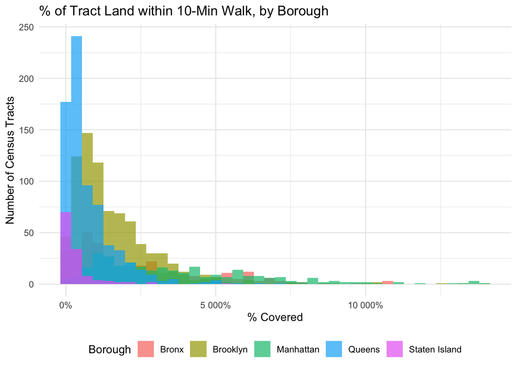

Healthcare Access Coverage by NYC Borough

```r
dist_plot <- tracts_final %>%
  st_drop_geometry() %>%
  filter(!is.na(perc_covered)) %>%
  ggplot(aes(x = perc_covered, fill = borough)) +
  geom_histogram(bins = 40, alpha = 0.7, position = "identity") +
  scale_x_continuous(labels = percent_format()) +
  labs(
    title = "% of Tract Land within 10-Min Walk, by Borough",
    x = "% Covered",
    y = "Number of Census Tracts",
    fill = "Borough"
  ) +
  theme_minimal(base_size = 11) +
  theme(legend.position = "bottom")

dist_plot
```

## 4.2 Exploratory: Poverty vs. Healthcare Access (Relationship Visualization)

**Scatterplot: poverty rate vs. access coverage (by borough)**

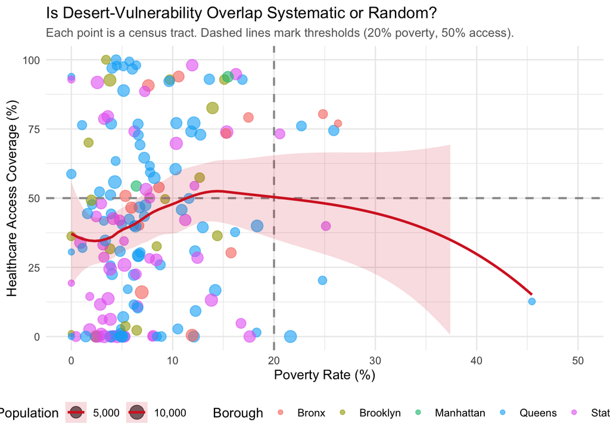

Is Desert-Vulnerability Overlap Systematic or Random? Poverty vs. Healthcare Access

```r
scatter_poverty_access <- tracts_final %>%
  st_drop_geometry() %>%
  filter(!is.na(pct_poverty), !is.na(perc_covered)) %>%
  ggplot(aes(x = pct_poverty * 100, y = perc_covered * 100,
             color = borough, size = population)) +
  geom_point(alpha = 0.6, stroke = 0.5) +
  geom_vline(xintercept = 20, linetype = "dashed", color = "gray60", linewidth = 0.8) +
  geom_hline(yintercept = 50, linetype = "dashed", color = "gray60", linewidth = 0.8) +
  geom_smooth(aes(color = NULL), method = "loess", color = "#d62728",
              fill = "#d62728", alpha = 0.15, se = TRUE, linewidth = 1) +
  scale_size_continuous(name = "Population", breaks = c(5000, 10000, 20000),
                        range = c(2, 6), labels = label_comma()) +
  scale_x_continuous("Poverty Rate (%)", limits = c(0, 50)) +
  scale_y_continuous("Healthcare Access Coverage (%)", limits = c(0, 100)) +
  labs(
    title = "Is Desert-Vulnerability Overlap Systematic or Random?",
    subtitle = "Each point is a census tract. Dashed lines mark thresholds (20% poverty, 50% access).",
    color = "Borough"
  ) +
  theme_minimal(base_size = 11) +
  theme(
    legend.position = "bottom",
    plot.subtitle = element_text(size = 10, color = "gray40")
  )

scatter_poverty_access
```

## 4.3 Top 5 Healthcare Deserts

[figure not shown]

```r
# First get the 5 worst tracts
top5_deserts <- tracts_final %>%
  st_drop_geometry() %>%
  arrange(perc_covered) %>%
  slice_head(n = 5) %>%
  mutate(rank = row_number(), .before = 1) %>%       # nice ranking
  select(GEOID, perc_covered, rank)

# Join the rank back to the spatial data so we can label nicely
tracts_with_rank <- tracts_final %>%
  left_join(top5_deserts %>% select(GEOID, rank, perc_covered), by = "GEOID") %>%
  mutate(is_top5 = !is.na(rank))

# Create the small-multiple map with context
top5_map <- ggplot() +
  # Light gray background for all other tracts (context)
  geom_sf(data = tracts_final, fill = "grey95", color = "white", linewidth = 0.2) +

  # Highlight the desert tract in each facet
  geom_sf(data = tracts_with_rank %>% filter(is_top5),
          fill = "#de2d26", color = "black", linewidth = 0.6) +

  # One panel per desert
  facet_wrap(~ reorder(paste0("#", rank, " – ", GEOID), rank), ncol = 5) +

  # Optional: add the % covered as subtitle
  labs(title = "Top 5 Healthcare Deserts (Lowest % Population with 30-min Access)",
       caption = "Red = selected tract | Gray = all other tracts") +

  theme_void(base_size = 11) +
  theme(
    strip.text = element_text(face = "bold", size = 10),
    plot.title = element_text(hjust = 0.5, face = "bold"),
    legend.position = "none",
    plot.margin = margin(10, 10, 10, 10)
  )

top5_map
```

# 5 OVERLAP ANALYSIS: Desert Tracts × Vulnerable Populations

## 5.1 Define Vulnerability & Compute Overlap

**Define thresholds and compute desert-vulnerability overlap**

```r
tracts_final <- tracts_final %>%
  mutate(
    is_desert = perc_covered < 0.50,

    # Define vulnerability indicators
    high_poverty = pct_poverty >= 0.20,
    minority_concentrated = pct_nonwhite >= 0.60,
    high_uninsured = pct_uninsured >= 0.15,

    # Combined: meets ANY criterion
    meets_vulnerability_criterion =
      high_poverty | minority_concentrated | high_uninsured,

    # Count how many criteria each tract meets
    vulnerability_criteria_count =
      as.numeric(high_poverty) +
      as.numeric(minority_concentrated) +
      as.numeric(high_uninsured)
  ) %>%
  # Label for viz
  mutate(
    vulnerability_profile = case_when(
      vulnerability_criteria_count == 3 ~ "Triple Burden",
      vulnerability_criteria_count == 2 ~ "Double Burden",
      vulnerability_criteria_count == 1 ~ "Single Burden",
      TRUE ~ "Low Vulnerability"
    )
  )

overlap_summary <- tracts_final %>%
  st_drop_geometry() %>%
  filter(!is.na(is_desert)) %>%
  summarise(
    # Total counts
    n_total = n(),
    n_desert = sum(is_desert == TRUE, na.rm = TRUE),
    n_non_desert = sum(is_desert == FALSE, na.rm = TRUE),

    # Vulnerability among DESERT tracts only
    n_desert_high_poverty = sum(is_desert & high_poverty, na.rm = TRUE),
    pct_desert_high_poverty =
      round(100 * n_desert_high_poverty / n_desert, 1),

    n_desert_minority = sum(is_desert & minority_concentrated, na.rm = TRUE),
    pct_desert_minority =
      round(100 * n_desert_minority / n_desert, 1),

    n_desert_high_uninsured = sum(is_desert & high_uninsured, na.rm = TRUE),
    pct_desert_high_uninsured =
      round(100 * n_desert_high_uninsured / n_desert, 1),

    n_desert_any_vulnerability = sum(is_desert & meets_vulnerability_criterion, na.rm = TRUE),
    pct_desert_any_vulnerability =
      round(100 * n_desert_any_vulnerability / n_desert, 1),

    # "Triple burden" (meets all three criteria)
    n_desert_triple_burden = sum(is_desert & vulnerability_criteria_count == 3, na.rm = TRUE),
    pct_desert_triple_burden =
      round(100 * n_desert_triple_burden / n_desert, 1)
  )

cat("Total NYC census tracts:", overlap_summary$n_total, "\n")
```

```
Total NYC census tracts: 2327
```

**Define thresholds and compute desert-vulnerability overlap**

```r
cat("Healthcare deserts (<50% access):", overlap_summary$n_desert, "\n")
```

```
Healthcare deserts (<50% access): 141
```

**Define thresholds and compute desert-vulnerability overlap**

```r
cat("\nOF THE", overlap_summary$n_desert, "DESERT TRACTS:\n")
```

```
OF THE 141 DESERT TRACTS:
```

**Define thresholds and compute desert-vulnerability overlap**

```r
cat("  ·", overlap_summary$pct_desert_high_poverty, "% (n=", overlap_summary$n_desert_high_poverty,
    ") are HIGH-POVERTY (≥20%)\n")
```

```
  · 2.8 % (n= 4 ) are HIGH-POVERTY (≥20%)
```

**Define thresholds and compute desert-vulnerability overlap**

```r
cat("  ·", overlap_summary$pct_desert_minority, "% (n=", overlap_summary$n_desert_minority,
    ") are MINORITY-CONCENTRATED (≥60% nonwhite)\n")
```

```
  · 19.1 % (n= 27 ) are MINORITY-CONCENTRATED (≥60% nonwhite)
```

**Define thresholds and compute desert-vulnerability overlap**

```r
cat("  ·", overlap_summary$pct_desert_high_uninsured, "% (n=", overlap_summary$n_desert_high_uninsured,
    ") have HIGH UNINSURED (≥15%)\n")
```

```
  · 0 % (n= 0 ) have HIGH UNINSURED (≥15%)
```

**Define thresholds and compute desert-vulnerability overlap**

```r
cat("  ·", overlap_summary$pct_desert_any_vulnerability, "% (n=", overlap_summary$n_desert_any_vulnerability,
    ") meet AT LEAST ONE criterion\n")
```

```
  · 20.6 % (n= 29 ) meet AT LEAST ONE criterion
```

**Define thresholds and compute desert-vulnerability overlap**

```r
cat("  ·", overlap_summary$pct_desert_triple_burden, "% (n=", overlap_summary$n_desert_triple_burden,
    ") meet ALL THREE criteria (triple burden)\n\n")
```

```
  · 0 % (n= 0 ) meet ALL THREE criteria (triple burden)
```